# Predict ADR

Alexander Noll

21 April 2016

# Question

The question we ask here is the following:

> If we train a model for predicting adverse drug reaction from Twitter data generated in 2013, are the results still valid nowadays?

This question is of critical importance to the research program initiated by the papers mentioned in our text: if the language in social media changes so drastically over few years that models trained on old data are not valid anymore, this means that experts have to annotate quite large amounts of tweets on a regular basis to have valid training samples.

A more refined version of the question above is:

> Are the quantitative measures “precision”, “recall”, “F-score” and “auc” when the model is evaluated on recent data significantly lower than on the validation set used in the original studies?

A quantitative way of evaluating this question is to train several models on the older dataset and compare the various scores.

# Data

The next step is to process the data. We wrote helper functions (`parse_diego_data` and `parse_binary_data`) that read in the data and return tidy data, i.e. one observation (tweet) per row. The dataset containing detailed annotations comes already split into two pieces.

```r
tidy_data <- function() {
    # Prepares two tidy datasets: training set and test set
    #
    # Args: None
    #
    # Returns: list whose first entry is the training set and whose second
    #          entry is the test set

    # Read dataset that is annotated in detail
    train_data_annotated <-
        parse_diego_data("train") %>%
        mutate(is_AE = as.factor(ifelse(!is.na(start_offset), "Yes", "No")))

    test_data_annotated <-
        parse_diego_data("test") %>%
        mutate(is_AE = as.factor(ifelse(!is.na(start_offset), "Yes", "No")))

    # Read binary annotated dataset
    binary_data <- parse_binary_data()
    binary_train_ind <- createDataPartition(binary_data$is_AE, p = 0.75, list = FALSE)

    # Bind two sets
    train_data <-
        bind_rows(train_data_annotated,
                  binary_data %>% slice(binary_train_ind)
                  ) %>%
        select(tweet_id, user_id, tweet_text, is_AE)

    test_data <-
        bind_rows(test_data_annotated,
                  binary_data %>% slice(-binary_train_ind)
                  )  %>%
        select(tweet_id, user_id, tweet_text, is_AE)

    train_data$is_AE %<>% as.factor
    test_data$is_AE %<>% as.factor

    # Remove drugs from text
    drugs <- read_lines("../data/download_tweets/drug_names.txt", skip = 6)
    drug_regex <- drugs %>% str_c(collapse = "|") %>% str_c("(", ., ")")

    train_data$tweet_text %<>% str_to_lower %>%  str_replace_all(drug_regex, "")
    test_data$tweet_text %<>% str_to_lower %>%  str_replace_all(drug_regex, "")

    list(train = train_data, test = test_data)


}

data <- tidy_data()
```

The dataset consists at this stage of the following four features:

| Column name | Description |
| --- | --- |
| tweet_id | Unique identifier of the tweet |
| user_id | Unique identifier of the user posting the tweet |
| tweet_text | Actual tweet text |
| is_AE | Is the tweet related to an adverse event |

# Exploratory data analysis

Let us first do exploratory data analysis on the tweets. One very popular method for this is to use **wordclouds**. We first produce two wordclouds: one (in black) with tweets not related to an AE and one (in green) related to adverse events. We see that there are interesting differences between the two wordclouds.

- The right one contains many more “negative” words and words that are obviously related to not feeling good
- The left wordcloud contains many neutral words, but also many negative words. These negative words, however are not related to an adverse event (consider, e.g. the phrase “depression hurts cymbalta can help”)

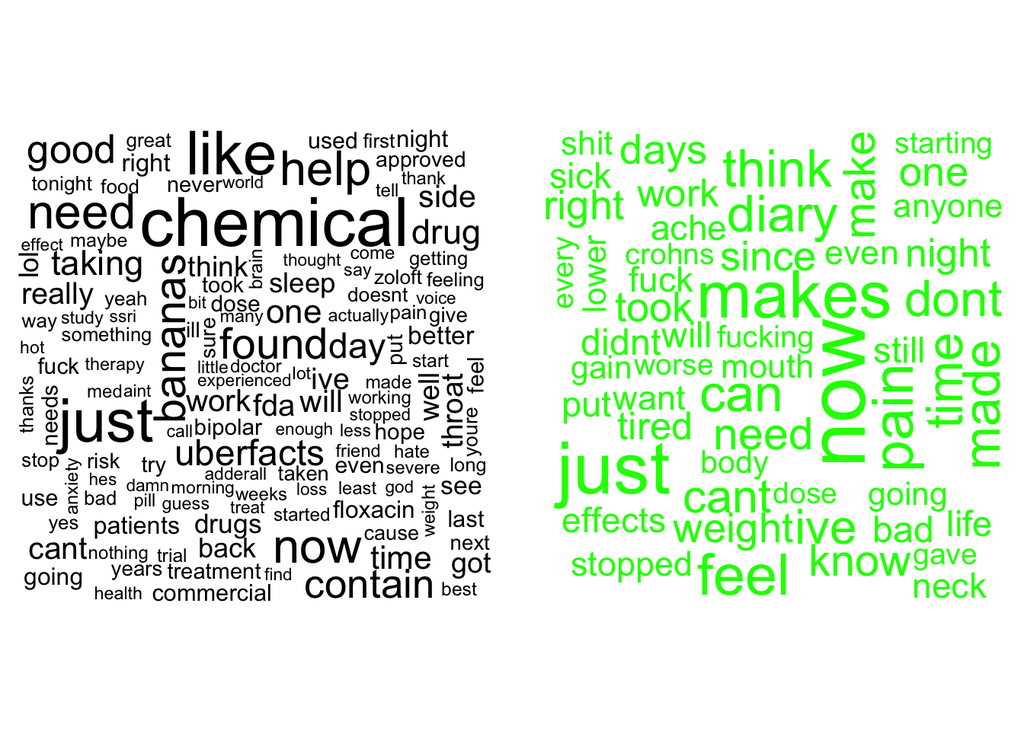

```r
pal <- brewer.pal(8, "Spectral")

par(mfrow = c(1, 2))
wordcloud(data[["train"]] %>% filter(is_AE == "No") %$% tweet_text,
          min.freq = 20,
          random.color = TRUE,
          colors = "black"
          )

wordcloud(data[["train"]] %>% filter(is_AE == "Yes") %$% tweet_text,
          min.freq = 20,
          random.color = TRUE,
          colors = "green"
          )
```

# Modeling

## Documenttermmatrix

The first step consists in preparing the **document term matrix** (DTM). This is a matrix whose columns corresponds to features of the text. The text is preprocessed here:

- Remove numbers
- Remove punctuation
- make everything lowercase
- [stem word](https://en.wikipedia.org/wiki/Word_stem)
- strip whitespace

After these steps, features are created from the text:

- Each word stem gives a feature, i.e. the feature matrix will have as many columns as there are distinct word stems in the corpus
- The value of each feature for each document (tweet) can be computed in various ways:
- one-hot-encoding: it is one if the word stem is in the tweet, 0 else
- Term frequency: the value of the feature is the number of times the word stem has occured in the tweet
- Term frequency inverse document frequency (*TfIdf*): this is a measure for the relative importance of the feature taking into account the frequency of the word stem in the entire corpus. For example, the word **the** may occur very frequently in a tweet, but it occurs also very often in the corpus. Thus its TfIdf will be low. On the other hand, if a word occurs often within a given tweet, but very rarely in the entire document, this means that the tweet is likely to be about this word and thus it obtains a high TfIdf.

We chose *Term Frequency* here to build the feature vectors. The reason is simple: the other approaches were tried, but using cross validation, Tf performed best.

```r
doc_matrix <- create_matrix(c(data[["train"]]$tweet_text,
                              data[["test"]]$tweet_text),
                            language = "english",
                            removeNumbers = TRUE,
                            removePunctuation = TRUE,
                            toLower = TRUE,
                            stemWords = TRUE,
                            stripWhitespace = TRUE,
                            ngramLength = 1,
                            minDocFreq = 1,
                            weighting = tm::weightTf)
```

## Container

Now that we have a DTM, we could use it directly as a feature matrix and train a model using, e.g. the `caret` package. The package `RTextTools`, however, has a very convenient datastructure allowing us to put all important data into one **container**. In the folowing code chunk, we put the tweets and the outcome in the container, specifying which data are training data and which data are test data. The option `virgin = FALSE` specifies that we have full information about the outcomes on the test data.

```r
container <-
    create_container(doc_matrix,
                     c(data[["train"]]$is_AE, data[["test"]]$is_AE),
                     trainSize = 1:nrow(data[["train"]]),
                     testSize = 1:nrow(data[["test"]]) + nrow(data[["train"]]),
                     virgin = FALSE)
```

## Model training

Using the container described above, we can directly train models. Here, we train four different models (training the other models is quite slow and does not significantly improve the performance) using the standard parameters:

- MAXENT: Maximum Entropy
- GLMNET: this is a regularized version of logistic regression
- SVM: regularized support vector machine
- TREE: decision tree

```r
fit_models <-
    train_models(container,
                 c("MAXENT", "GLMNET", "SVM", "TREE"),
                 cost = 1000)
```

## Model prediction

The `RTextTools` package also allows us to make predictions quite easily. The following code chunk produces the results (i.e. predicted probability and predicted label) for each of the four models on the test set:

```r
preds <- classify_models(container, fit_models)
```

## Model evaluation

The next step is to evaluate the quality of the models. We start with AUC:

```r
par(mfrow = c(2, 2))
preds %$% roc(data[["test"]]$is_AE, MAXENTROPY_PROB) %>% plot
```

```
##
## Call:
## roc.default(response = data[["test"]]$is_AE, predictor = MAXENTROPY_PROB)
##
## Data: MAXENTROPY_PROB in 1011 controls (data[["test"]]$is_AE No) < 327 cases (data[["test"]]$is_AE Yes).
## Area under the curve: 0.4718
```

```r
preds %$% roc(data[["test"]]$is_AE, GLMNET_PROB) %>% plot
```

```
##
## Call:
## roc.default(response = data[["test"]]$is_AE, predictor = GLMNET_PROB)
##
## Data: GLMNET_PROB in 1011 controls (data[["test"]]$is_AE No) > 327 cases (data[["test"]]$is_AE Yes).
## Area under the curve: 0.825
```

```r
preds %$% roc(data[["test"]]$is_AE, SVM_PROB) %>% plot
```

```
##
## Call:
## roc.default(response = data[["test"]]$is_AE, predictor = SVM_PROB)
##
## Data: SVM_PROB in 1011 controls (data[["test"]]$is_AE No) > 327 cases (data[["test"]]$is_AE Yes).
## Area under the curve: 0.7523
```

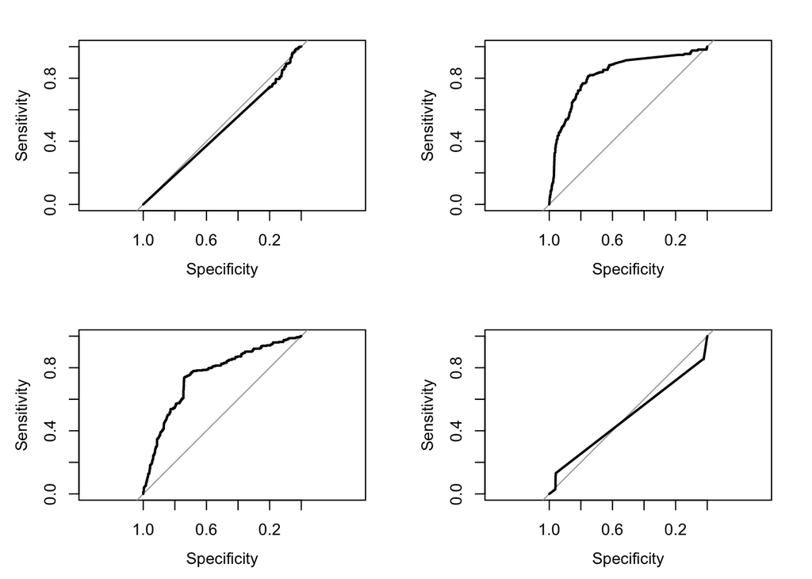

```
##
## Call:
## roc.default(response = data[["test"]]$is_AE, predictor = TREE_PROB)
##
## Data: TREE_PROB in 1011 controls (data[["test"]]$is_AE No) < 327 cases (data[["test"]]$is_AE Yes).
## Area under the curve: 0.4844
```

```r
preds %$% roc(data[["test"]]$is_AE, TREE_PROB) %>% plot
```

We see that the regularized logistic regression performs best with quite a high area under the curve.

Next, the `RTextTools` package allows us to extract important other measures as well quite easily using the `create_analytics` command. This gives us the precision, recall and f-score for each of the models (recall that the f-score is a weighted average of the precision and the recall).

Also it automatically creates an **ensemble summary**. This is a useful statistics about the combined performance of all four models. The line corresponding to `n >= 2` means the following:

- Coverage tells us on how many percent of the documents two ore more models agree.
- The recall value corresponds to the recall statistics when restricted to those documents.

```r
analytics <- create_analytics(container, preds)
```

```r
summary(analytics)
```

```
## ENSEMBLE SUMMARY
##
##        n-ENSEMBLE COVERAGE n-ENSEMBLE RECALL
## n >= 1                1.00              0.84
## n >= 2                1.00              0.84
## n >= 3                0.93              0.88
## n >= 4                0.74              0.92
##
##
## ALGORITHM PERFORMANCE
##
##        SVM_PRECISION           SVM_RECALL           SVM_FSCORE
##                0.840                0.765                0.790
##     GLMNET_PRECISION        GLMNET_RECALL        GLMNET_FSCORE
##                0.840                0.690                0.720
##       TREE_PRECISION          TREE_RECALL          TREE_FSCORE
##                0.775                0.625                0.645
## MAXENTROPY_PRECISION    MAXENTROPY_RECALL    MAXENTROPY_FSCORE
##                0.765                0.780                0.770
```

```r
create_ensembleSummary(analytics@document_summary)
```

```
##        n-ENSEMBLE COVERAGE n-ENSEMBLE RECALL
## n >= 1                1.00              0.84
## n >= 2                1.00              0.84
## n >= 3                0.93              0.88
## n >= 4                0.74              0.92
```

## Aggregating predictions:

The next step is to aggregate the predictions from different models into a final model.

```r
preds$results <- data[["test"]]$is_AE
tr_control <- trainControl(method = "cv",
                           number = 10,
                           summaryFunction = twoClassSummary,
                           classProbs = TRUE)

tune_grid <- expand.grid(mtry = c(1, 2, 3, 4))

fit_rf<- train(results ~ MAXENTROPY_PROB + GLMNET_PROB + SVM_PROB + TREE_PROB,
                 data = preds,
                 method = "rf",
                 trControl = tr_control,
                 tuneGrid = tune_grid
                 )
```

We look at the results:

```r
fit_rf
```

[output not shown]

```r
varImp(fit_rf)
```

```
## rf variable importance
##
##                 Overall
## GLMNET_PROB     100.000
## SVM_PROB         70.259
## TREE_PROB         3.562
## MAXENTROPY_PROB   0.000
```

The area under curve is slightly below 90%.

# Recent data

The next step consists in checking whether we can reproduce these results with recently collected twitter data.

```r
parse_new_tweets <- function() {
    # Prepares new tweets into a form that is suitable for being fed
    # into the classifiers
    #
    # Args: None
    #
    # Returns: data frame
    load("../data/download_tweets/datacollection.RData")
    tweets_text <- map_chr(tweets, ~.$text)

    # Remove drugs from text
    drugs <- read_lines("../data/download_tweets/drug_names.txt", skip = 6)
    drug_regex <- drugs %>% str_c(collapse = "|") %>% str_c("(", ., ")")

    tweets_text %<>% str_to_lower %>%  str_replace_all(drug_regex, "")

    tweets_text
}

new_tweets <- parse_new_tweets()
```

In order for the following code chunk to work, the [linked hack](https://groups.google.com/forum/embed/#!topic/rtexttools-help/Drqr3Z897Mk) has to be performed. Furthermore, we have to change the encoding to UTF-8.

```r
source("../r/helper_functions/create_matrix_fixed.R")
n_new_tweets <- 200
new_tweets_dtm <-
    create_matrix(new_tweets %>% head(n = n_new_tweets),
                  originalMatrix = doc_matrix,
                  language = "english",
                  removeNumbers = TRUE,
                  removePunctuation = TRUE,
                  toLower = TRUE,
                  stemWords = TRUE,
                  stripWhitespace = TRUE,
                  ngramLength = 1,
                  minDocFreq = 1,
                  weighting = tm::weightTf)
```

```r
new_container <- create_container(new_tweets_dtm,
                                  labels = c(data[[1]]$is_AE, data[[2]]$is_AE),
                                  trainSize = NULL,
                                  testSize = 1:n_new_tweets,
                                  virgin = TRUE
                                  )
```

```r
preds_new <- classify_models(new_container, fit_models)
preds_new_final <- predict(fit_rf, preds_new, type = "prob")
```

```r
order(preds_new_final[, 2], decreasing = TRUE) %>%
    head(n = 30) %>%
    map_chr(~new_tweets[.])
```

```
##  [1] "i am pretty sure that i just injected molten lava (aka ) into my body.  #rawarrior #greatballsoffire"
##  [2] "hey, we can manage your skin rash but you'll probably get cancer. deal? #"
##  [3] "@us_fda\nwhy do you allow /the msm to advertise devastating  side effects using loud background music drowning out the warning?"
##  [4] "lmao  commercial this medicine is for ra side effects may cause irritabitlity swelling choking vomitting nausea death lmao"
##  [5] "after a full year off meds, i can look forward to some pain free days!thanks @hahsupport for great service! # #nhs #energy #happy #psa"
##  [6] "dude: if i'm feeling any side effects from - i'm out."
##  [7] "if you missed my broadcast make sure to become a fan. my musically is "
##  [8] "@colin_smith84 i too failed on  &amp; infliximab so i feel your pain! hope all goes well - let me know how you get on ��"
##  [9] "@peter_cannes only initial side effects i had was increased heart rate. no other issues yet. and it's not as painful as ."
## [10] "had my first 4 # injections today, feeling like a boss! now en-route to my audition with some decent eye candy... #fitticketinspector"
## [11] "unboxing a 3 month supply of weekly  injections\n#ibd #crohns #invisibleillness https://t.co/qhtr3o1jdp"
## [12] " injection tonight with a side of @docker and @rabbitmq experimentation. hoping i might feel a tad less pained tomorrow\n#crohnsdev"
## [13] "@frasmaxi @crohnscolitisuk tried to restart treatment but i had a massive allergic reaction, on  now, not as effective but ok 2/2"
## [14] "rt @jesspwhite:  injection tonight with a side of @docker and @rabbitmq experimentation. hoping i might feel a tad less pained tomorr…"
## [15] "rt @jesspwhite:  injection tonight with a side of @docker and @rabbitmq experimentation. hoping i might feel a tad less pained tomorr…"
## [16] "rt @colin_smith84: have 1st vedolizumab infusion tm after failing infliximab &amp; .i have crohns in small bowel. how quickly will it tak…"
## [17] "rt @colin_smith84: have 1st vedolizumab infusion tm after failing infliximab &amp; .i have crohns in small bowel. how quickly will it tak…"
## [18] "have 1st vedolizumab infusion tm after failing infliximab &amp; .i have crohns in small bowel. how quickly will it take to work? #ibdchat"
## [19] "@hurtblogger @wheresrosinow @meetrobertsmith maybe  makes something similar?"
## [20] "@curiouslyamazed i think i've decided mtx. if i get antibodies to remicade i'll probably end up with  shots plus mtx shots."
## [21] "@mykl0 that's awful. my gi just bitched me out for being out of remission and he's the one that took me off . i'm like thanks doc"
## [22] "@exlibris would you do a clinical trial? i've seen one recently but  has been working for me so i didn't qualify"
## [23] "maybe the reason why my stomach gets so upset the day after my # shot is because it has mannitol in it #fructose #indcolitis"
## [24] "my  shot didn't hurt this time! i'm so glad i have the greatest support system like @tylervandiver and helping me also to do the shot"
## [25] "i started  about a month ago. with the plaquenil, mobiq, and methotrexate i am on im in a lot less pain. i... https://t.co/isurg4itml"
## [26] "so, my first round of  was absolutely terrible. literally never felt pain like that."
## [27] "it's wednesday, so you know what that means... #crohnsdisease #crohns # https://t.co/4lzbysaofr"
## [28] "rt @musy_d: #ibdchat been on  for nearly 7 years with crohn's do you think i'll be on it for life?"
## [29] "rt @musy_d: #ibdchat been on  for nearly 7 years with crohn's do you think i'll be on it for life?"
## [30] "#ibdchat been on  for nearly 7 years with crohn's do you think i'll be on it for life?"
```